# Unsupervised Possibilistic Fuzzy C-Means Algorithm

Zeynel Cebeci

2017-11-22

# 1 PREPARING FOR THE ANALYSIS

## 1.1 Install and load the package ppclust

This vignette is designed to be used with the ‘`ppclust`’ package. You can download the recent version of the package from CRAN with the following command:

```r
install.packages("ppclust")
```

If you have already installed ‘`ppclust`’, you can load it into R working environment by using the following command:

```r
library(ppclust)
```

## 1.2 Load the required packages

For visualization of the clustering results, some examples in this vignette use the functions from some cluster analysis packages such as ‘`cluster`’, ‘`fclust`’ and ‘`factoextra`’. Therefore, these packages should be loaded into R working environment with the following commands:

```r
library(factoextra)
library(cluster)
library(fclust)
```

## 1.3 Load the data set

We demonstrate UPFC on the Iris data set (Anderson, 1935). It is a real data set of the four features (Sepal.Length, Sepal.Width, Petal.Length and Petal.Width) of three species (in the last column as the class variable). This four-dimensional data set contains totally 150 observations as 50 samples from each of three iris species. One of these three natural clusters (Class 1) is linearly well-separated from the other two clusters, while Classes 2 and 3 have some overlap as seen in the plot below.

```r
data(iris)
x=iris[,-5]
x
```

| Sepal.Length | Sepal.Width | Petal.Length | Petal.Width |
| --- | --- | --- | --- |
| 5.1 | 3.5 | 1.4 | 0.2 |
| 4.9 | 3.0 | 1.4 | 0.2 |
| 4.7 | 3.2 | 1.3 | 0.2 |
| 4.6 | 3.1 | 1.5 | 0.2 |
| 5.0 | 3.6 | 1.4 | 0.2 |
| 5.4 | 3.9 | 1.7 | 0.4 |
| 4.6 | 3.4 | 1.4 | 0.3 |
| 5.0 | 3.4 | 1.5 | 0.2 |
| 4.4 | 2.9 | 1.4 | 0.2 |
| 4.9 | 3.1 | 1.5 | 0.1 |

[output cut: 140 more lines]

Plot the data by the classes of iris species

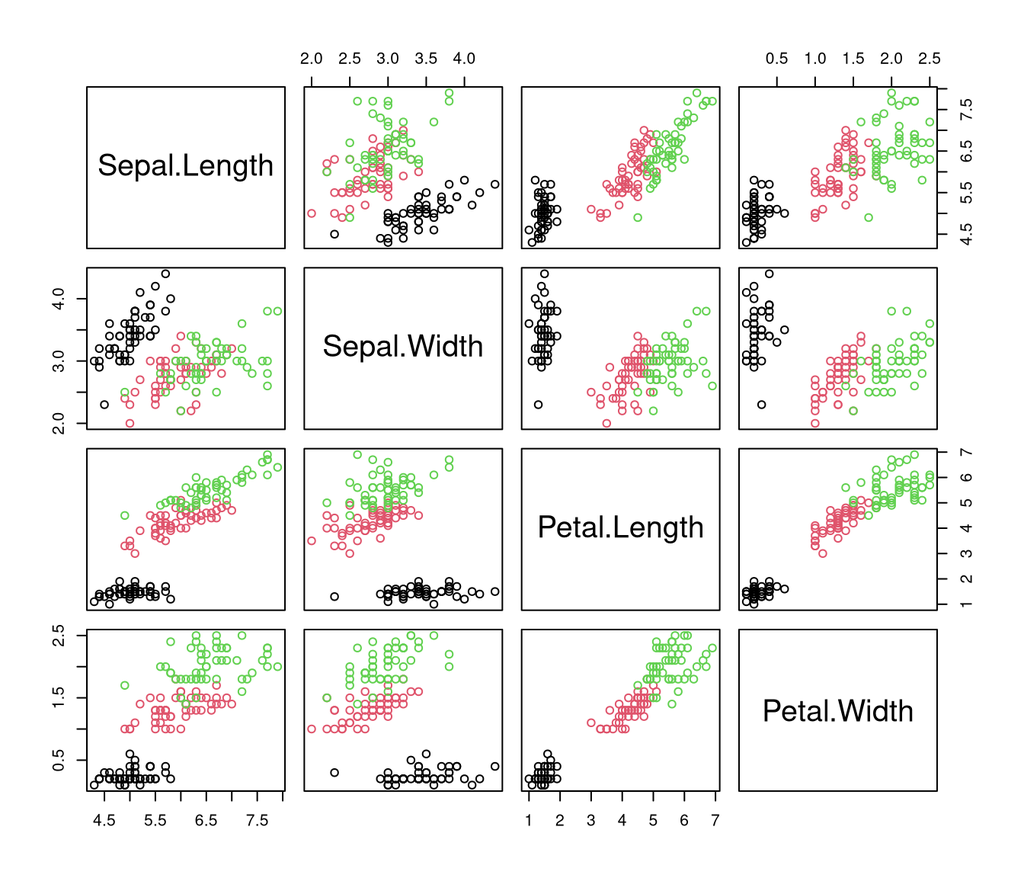

```r
pairs(x, col=iris[,5])
```

# 2 UNSUPERVISED POSSIBILISTIC FUZZY C-MEANS CLUSTERING

Unsupervised Possibilistic Fuzzy C-Means (UPFC) is an extension of Possibilistic Clustering Algorithm (PCA) by Yang & Wu (2006). Wu et al (2010) reported that PCA is very sensitive to initializations and sometimes generates coincident clusters. They proposed the algorithm UPFC to overcome this problem with inspiration by Pal et al’s PFCM algorithm (Pal et al, 2005). The algorithm UPFC produces both possibilistic and probabilistic memberships simultaneously, and overcomes the noise sensitivity problem of FCM and the coincident clusters problem of PCA.

## 2.1 Run UPFC with Single Start

### 2.1.1 Initialization

In order to start UPFC, an initialization step is required to build the initial cluster prototypes matrix and fuzzy membership degrees matrix. Although this task is usually performed in the initialization step of the clustering algorithm, the initial prototypes and memberships can also be directly input by the user.

UPFC is usually started by using an integer specifying the number of clusters. In this case, the prototypes matrix is internally generated by using any of the prototype initalization algorithms which are included in the package ‘`inaparc`’. The default initialization technique is *K-means++* with the current version of `fcm` function in this package. In the following code block, FCM runs for three clusters with the default values of the remaining arguments.

```r
res.upfc <- upfc(x, centers=3)
```

Although it is a usual way to run UPFC with a pre-determined number of clusters, sometimes the users may wish to use a certain cluster prototypes matrix to start the algorithm. In this case, UPFC uses the user-specified prototype matrix instead of internally generated ones as follows:

```r
v0 <- matrix(nrow=3, ncol=4,
     c(5.0, 3.4, 1.4, 0.3,
       6.7, 3.0, 5.6, 2.1,
       5.8, 2.7, 4.3, 1.4),
       byrow=TRUE)
print(v0)
```

```
##      [,1] [,2] [,3] [,4]
## [1,]  5.0  3.4  1.4  0.3
## [2,]  6.7  3.0  5.6  2.1
## [3,]  5.8  2.7  4.3  1.4
```

```r
res.upfc <- upfc(x, centers=v0)
```

In the following code block, there is another example for initialization of cluster prototypes for three clusters. `v`, the cluster prototype matrix is initialized by using the *K-means++* initalization algorithm (`kmpp`) in the R package ‘`inaparc`’.

```r
v0 <- inaparc::kmpp(x, k=3)$v
print(v0)
```

```
##      Sepal.Length Sepal.Width Petal.Length Petal.Width
## Cl.1          7.7         2.6          6.9         2.3
## Cl.2          5.4         3.4          1.5         0.4
## Cl.3          6.4         3.2          4.5         1.5
```

```r
res.upfc <- upfc(x, centers=v0)
```

> There are many other techniques for initialization of cluster prototype matrices in the R package ‘`inaparc`’. See the package documentation for other alternatives.

UPFC can be alternatively started with a user-specified membership degrees matrix. In this case, the function `fcm` is called with the argument `memberships` as follows:

```r
u0 <- inaparc::imembrand(nrow(x), k=3)$u
res.upfc <- upfc(x, centers=3, memberships=u0)
```

In order to generate the matrices of cluster prototypes and membership degrees, users can choose any of existing initialization algorithms in the R package ‘`inaparc`’. For this purpose, `alginitv` and `alginitu` can be speficied for cluster prototypes and membership degrees, respectively.

```r
res.upfc <- upfc(x, centers=3, alginitv="firstk", alginitu="imembrand")
```

In general, the squared Euclidean distance metric is used with UPFC in order to compute the distances between the cluster centers and the data objects. Users can specify the other distance metrics with the argument `dmetric` as follows:

```r
res.upfc <- upfc(x, centers=3, dmetric="euclidean")
```

Although the argument `m`, fuzzy exponent is usually choosen as `2` in most of the applications using PFCM, users can increase `m` to get more fuzzified results as follows:

```r
res.upfc <- upfc(x, centers=3, m=4)
```

However, large values of `m` reduce the effect of memberships on the prototypes and the model will behave more like the PCM model (Pal et al, 2005). The argument `eta`, typicality exponent should be usually choosen as `2` for UPFC, but users can change the `eta` as follows in order to achieve the different clustering results.

```r
res.upfc <- upfc(x, centers=3, eta=3)
```

In UPFC, the relative importance of probabilistic and possibilistic parts of the objective function can be changed by using `a` and `b` parameters, respectively. If $b=0$, and $\Omega_i=0$, UPFC behaves like to FCM. Contrarily, if $a=0$ UPFC becomes equivalent to PCM. In general these arguments are set to `2` as the default value, users can change them as follows:

```r
res.upfc <- upfc(x, centers=3, a=3, b=2)
```

> There are other input arguments available with the function `upfc` to control the run of UPFC algoritm. For the details, see the `upfc` section in the package manual of `ppclust`.

### 2.1.2 Clustering Results

#### 2.1.2.1 Fuzzy Membership Matrix

The fuzzy membership degrees matrix is one of the main outputs of the function `upfc`.

```r
res.upfc <- upfc(x, centers=3)
as.data.frame(res.upfc$u)
```

|  | Cluster 1 | Cluster 2 | Cluster 3 |
| --- | --- | --- | --- |
| 1 | 0.002248451 | 0.0011900194 | 0.996561530 |
| 2 | 0.015550571 | 0.0080242351 | 0.976425194 |
| 3 | 0.012814767 | 0.0068097154 | 0.980375517 |
| 4 | 0.021016844 | 0.0108476143 | 0.968135542 |
| 5 | 0.003640444 | 0.0019437909 | 0.994415765 |
| 6 | 0.043696583 | 0.0228787449 | 0.933424672 |
| 7 | 0.013165657 | 0.0069778530 | 0.979856490 |
| 8 | 0.000267323 | 0.0001385057 | 0.999594171 |
| 9 | 0.044950757 | 0.0236180488 | 0.931431194 |
| 10 | 0.011081000 | 0.0056840799 | 0.983234920 |

[output cut: 140 more lines]

#### 2.1.2.2 Typicality Degrees Matrix

The typicality degrees matrix of the function `upfc`.

```r
as.data.frame(res.upfc$t)
```

|  | Cluster 1 | Cluster 2 | Cluster 3 |
| --- | --- | --- | --- |
| 1 | 1.153879e-04 | 3.628715e-08 | 9.797503e-01 |
| 2 | 1.227010e-04 | 2.632576e-08 | 8.663850e-01 |
| 3 | 4.924827e-05 | 7.830448e-09 | 8.784034e-01 |
| 4 | 1.075846e-04 | 2.049583e-08 | 8.200776e-01 |
| 5 | 8.967697e-05 | 2.629939e-08 | 9.664585e-01 |
| 6 | 4.791942e-04 | 4.571315e-07 | 6.992044e-01 |
| 7 | 6.622221e-05 | 1.303657e-08 | 8.787184e-01 |
| 8 | 1.753447e-04 | 5.630194e-08 | 9.976897e-01 |
| 9 | 4.684103e-05 | 5.756702e-09 | 6.181088e-01 |
| 10 | 1.530292e-04 | 3.650009e-08 | 9.057381e-01 |

[output cut: 140 more lines]

#### 2.1.2.3 Initial and Final Cluster Prototypes

Initial and final cluster prototypes matrices can be achieved as follows:

```r
res.upfc$v0
```

```
##           Sepal.Length Sepal.Width Petal.Length Petal.Width
## Cluster 1          5.6         2.5          3.9         1.1
## Cluster 2          6.1         2.6          5.6         1.4
## Cluster 3          4.8         3.1          1.6         0.2
```

```r
res.upfc$v
```

```
##           Sepal.Length Sepal.Width Petal.Length Petal.Width
## Cluster 1     5.944440    2.791643     4.429674   1.4231306
## Cluster 2     6.629620    3.018968     5.478627   2.0051523
## Cluster 3     5.000576    3.411018     1.480558   0.2503315
```

#### 2.1.2.4 Summary of Clustering Results

The function `upfc` returns the clustering results as an intance of ‘`ppclust`’ class. This object is summarized with the `summary` method of the package ‘`ppclust`’ as follows:

```r
summary(res.upfc)
```

```
## Summary for 'res.upfc'
##
## Number of data objects:  150
##
## Number of clusters:  3
##
## Crisp clustering vector:
##   [1] 3 3 3 3 3 3 3 3 3 3 3 3 3 3 3 3 3 3 3 3 3 3 3 3 3 3 3 3 3 3 3 3 3 3 3 3 3
##  [38] 3 3 3 3 3 3 3 3 3 3 3 3 3 2 1 2 1 1 1 1 1 1 1 1 1 1 1 1 1 1 1 1 1 1 1 1 1
##  [75] 1 1 1 2 1 1 1 1 1 1 1 1 1 1 1 1 1 1 1 1 1 1 1 1 1 1 2 1 2 2 2 2 1 2 2 2 2
## [112] 2 2 1 2 2 2 2 2 1 2 1 2 1 2 2 1 1 2 2 2 2 2 2 2 2 2 2 1 2 2 2 1 2 2 2 2 2
## [149] 2 1
##
## Initial cluster prototypes:
##           Sepal.Length Sepal.Width Petal.Length Petal.Width
## Cluster 1          5.6         2.5          3.9         1.1
## Cluster 2          6.1         2.6          5.6         1.4
## Cluster 3          4.8         3.1          1.6         0.2
##
## Final cluster prototypes:
##           Sepal.Length Sepal.Width Petal.Length Petal.Width
## Cluster 1     5.944440    2.791643     4.429674   1.4231306
## Cluster 2     6.629620    3.018968     5.478627   2.0051523
## Cluster 3     5.000576    3.411018     1.480558   0.2503315
##
## Distance between the final cluster prototypes
##           Cluster 1 Cluster 2
## Cluster 2  1.960201
## Cluster 3 11.347243 21.871439
##
## Difference between the initial and final cluster prototypes
##           Sepal.Length Sepal.Width Petal.Length Petal.Width
## Cluster 1    0.3444400   0.2916432    0.5296736  0.32313065
## Cluster 2    0.5296201   0.4189683   -0.1213729  0.60515234
## Cluster 3    0.2005756   0.3110180   -0.1194416  0.05033154
##
## Root Mean Squared Deviations (RMSD): 0.7255796
## Mean Absolute Deviation (MAD): 5.127157
##
## Membership degrees matrix (top and bottom 5 rows):
```

[output cut: 20 more lines]

```
## Dunn's Fuzziness Coefficients:
## dunn_coeff normalized
##  0.6169534  0.4254301
##
## Within cluster sum of squares by cluster:
##        1        2        3
## 35.21241 29.10857 15.15100
## (between_SS / total_SS =  87.52%)
##
## Available components:
##  [1] "u"          "t"          "v"          "v0"         "d"
##  [6] "x"          "cluster"    "csize"      "sumsqrs"    "k"
## [11] "m"          "eta"        "a"          "b"          "beta"
## [16] "iter"       "best.start" "func.val"   "comp.time"  "inpargs"
## [21] "algorithm"  "call"
```

All available components of the ‘`ppclust`’ object are listed at the end of summary. These elements can be accessed using as the attributes of the object. For example, the execution time of the run of UPFC is accessed as follows:

```r
res.upfc$comp.time
```

```
## [1] 0.586
```

## 2.2 Run UPFC with Multiple Starts

In order to find an optimal solution, the function `upfc` can be started for multiple times. As seen in the following code chunk, the argument `nstart` is used for this purpose.

```r
res.upfc <- upfc(x, centers=3, nstart=4)
```

When the multiple start is performed, either initial cluster prototypes or initial membership degrees could be wanted to keep unchanged between the starts of algorithm. In this case, the arguments `fixcent` and `fixmemb` are used for fixing the initial cluster prototypes matrix and initial membership degrees matrix, respectively.

```r
res.upfc <- upfc(x, centers=3, nstart=4, fixmemb=TRUE)
```

> Both the prototypes and memberships cannot be fixed at the same time.

### 2.2.1 Display the best solution

The clustering result contains some outputs providing information about some components such as the objective function values, number of iterations and computing time obtained with each start of the algorithm. The following code chunk demonstrates these outputs.

```r
res.upfc$func.val
```

```
## [1] -186.3218 -149.4653 -186.3218 -186.3218
```

```r
res.upfc$iter
```

```
## [1]  57 132  59  60
```

```r
res.upfc$comp.time
```

```
## [1] 0.566 1.418 0.641 0.719
```

Among the outputs from succesive starts of the algorithm, the best solution is obtained from the start giving the minimum value of the objective function, and stored as the final clustering result of the multiple starts of UPFC.

```r
res.upfc$best.start
```

```
## [1] 4
```

### 2.2.2 Display the summary of clustering results

As described for the single start of UPFC above, the result of multiple starts of UPFC is displayed by using `summary` method of the ‘`ppclust`’ package.

```r
summary(res.upfc)
```

```
## Summary for 'res.upfc'
##
## Number of data objects:  150
##
## Number of clusters:  3
##
## Crisp clustering vector:
##   [1] 1 1 1 1 1 1 1 1 1 1 1 1 1 1 1 1 1 1 1 1 1 1 1 1 1 1 1 1 1 1 1 1 1 1 1 1 1
##  [38] 1 1 1 1 1 1 1 1 1 1 1 1 1 3 2 3 2 2 2 2 2 2 2 2 2 2 2 2 2 2 2 2 2 2 2 2 2
##  [75] 2 2 2 3 2 2 2 2 2 2 2 2 2 2 2 2 2 2 2 2 2 2 2 2 2 2 3 2 3 3 3 3 2 3 3 3 3
## [112] 3 3 2 3 3 3 3 3 2 3 2 3 2 3 3 2 2 3 3 3 3 3 3 3 3 3 3 2 3 3 3 2 3 3 3 3 3
## [149] 3 2
##
## Initial cluster prototypes:
##           Sepal.Length Sepal.Width Petal.Length Petal.Width
## Cluster 1          4.9         3.1          1.5         0.2
## Cluster 2          5.6         3.0          4.5         1.5
## Cluster 3          6.3         3.3          6.0         2.5
##
## Final cluster prototypes:
##           Sepal.Length Sepal.Width Petal.Length Petal.Width
## Cluster 1     5.000576    3.411018     1.480558   0.2503315
## Cluster 2     5.944440    2.791643     4.429674   1.4231306
## Cluster 3     6.629620    3.018968     5.478627   2.0051523
##
## Distance between the final cluster prototypes
##           Cluster 1 Cluster 2
## Cluster 2 11.347243
## Cluster 3 21.871439  1.960201
##
## Difference between the initial and final cluster prototypes
##           Sepal.Length Sepal.Width Petal.Length Petal.Width
## Cluster 1    0.1005756   0.3110180  -0.01944160  0.05033154
## Cluster 2    0.3444400  -0.2083568  -0.07032643 -0.07686935
## Cluster 3    0.3296201  -0.2810317  -0.52137286 -0.49484766
##
## Root Mean Squared Deviations (RMSD): 0.5735844
## Mean Absolute Deviation (MAD): 3.744309
##
## Membership degrees matrix (top and bottom 5 rows):
```

[output cut: 20 more lines]

```
## Dunn's Fuzziness Coefficients:
## dunn_coeff normalized
##  0.6169534  0.4254301
##
## Within cluster sum of squares by cluster:
##        1        2        3
## 15.15100 35.21241 29.10857
## (between_SS / total_SS =  87.52%)
##
## Available components:
##  [1] "u"          "t"          "v"          "v0"         "d"
##  [6] "x"          "cluster"    "csize"      "sumsqrs"    "k"
## [11] "m"          "eta"        "a"          "b"          "beta"
## [16] "iter"       "best.start" "func.val"   "comp.time"  "inpargs"
## [21] "algorithm"  "call"
```

# 3 VISUALIZATION OF THE CLUSTERING RESULTS

## 3.1 Pairwise Scatter Plots

There are many ways of visual representation of the clustering results. One common techique is to display the clustering results by using pairs of the features. The ‘`plotcluster`’ can be used to plot the clustering results as follows:

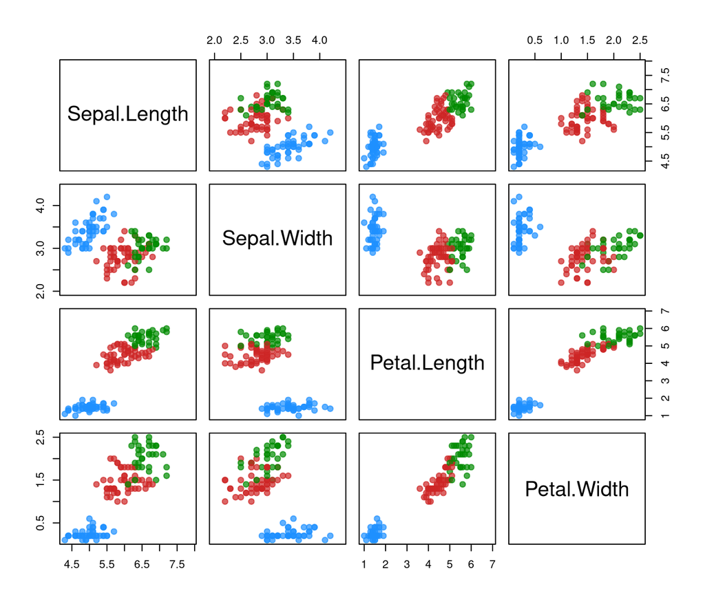

```r
plotcluster(res.upfc, cp=1, trans=TRUE)
```

In the above figure, the plot shows the data objects which have typicality degrees than 0.5 by using the color palette 1 and transparent colors. In order to filter the objects for different typicality degrees, the value of `tv` argument can be changed as follows:

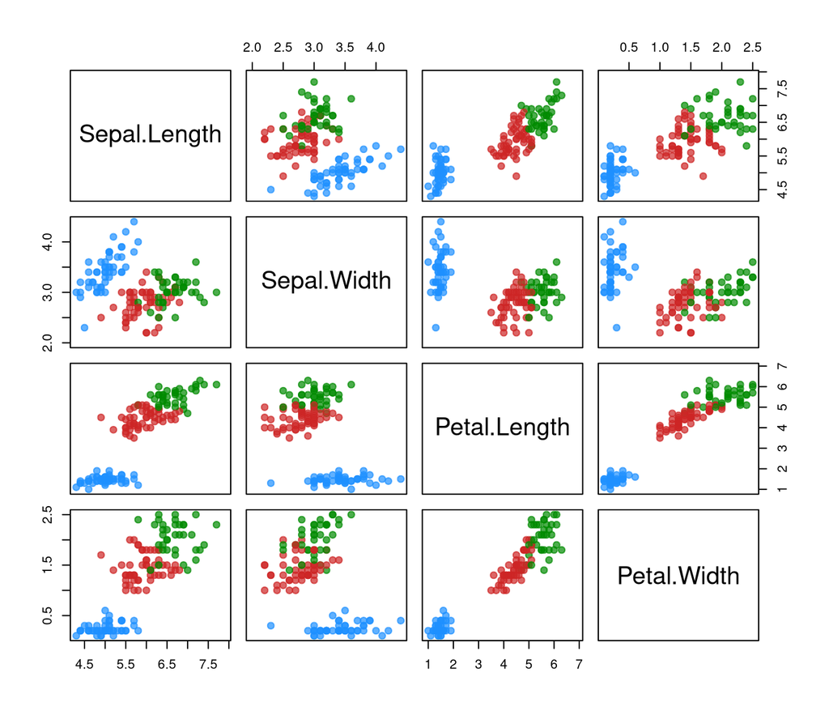

```r
plotcluster(res.upfc, cp=1, tv=0.25, trans=TRUE)
```

As default, the function `plotcluster` plots for the typicality degrees for the algorithm producing both fuzzy membership and typicality degrees such as FPCM and PFCM including UPFC. In order to plot using the fuzzy memberships, the argument `mt`, the membership type should be used with “u” option as follows:

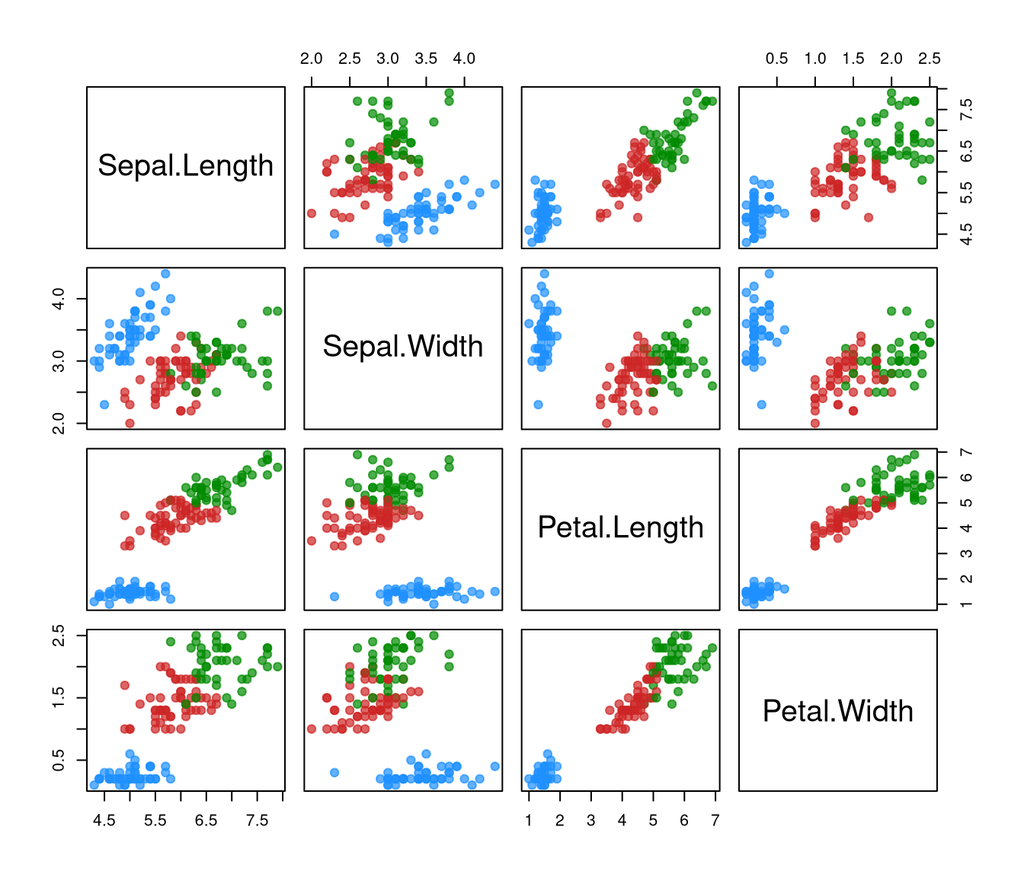

```r
plotcluster(res.upfc, mt="u", cp=1, trans=TRUE)
```

## 3.2 Cluster Plot with fviz_cluster

There are some nice versions of the cluster plots in some of the R packages. One of them is the function `fviz_cluster` of the package ‘`factoextra`’ (Kassambara & Mundt, 2017). In order to use this function for the fuzzy clustering result, first the fuzzy clustering object of `ppclust` should be converted to `kmeans` object by using the function `ppclust2` of the package ‘`ppclust`’ as shown in the first line of the code chunk below:

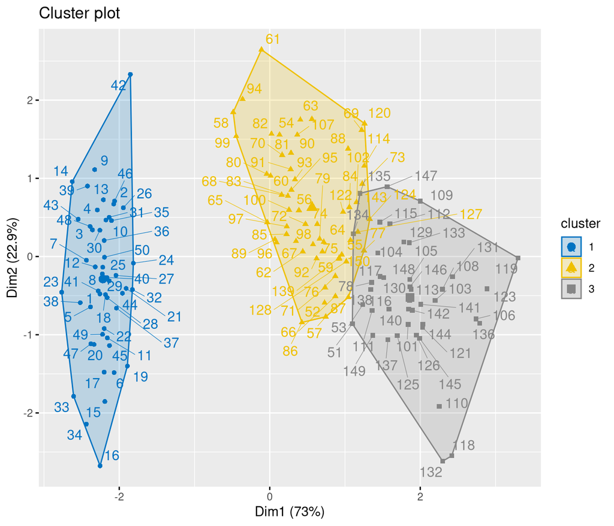

```r
res.upfc2 <- ppclust2(res.upfc, "kmeans")
factoextra::fviz_cluster(res.upfc2, data = x,
  ellipse.type = "convex",
  palette = "jco",
  repel = TRUE)
```

## 3.3 Cluster Plot with clusplot

User can also use the function `clusplot` in the package ‘`cluster`’ (Maechler et al, 2017) for plotting the clustering results. For this purpose, the fuzzy clustering object of `ppclust` should be converted to `fanny` object by using the `ppclust2` function of the package ‘`ppclust`’ as seen in the following code chunk.

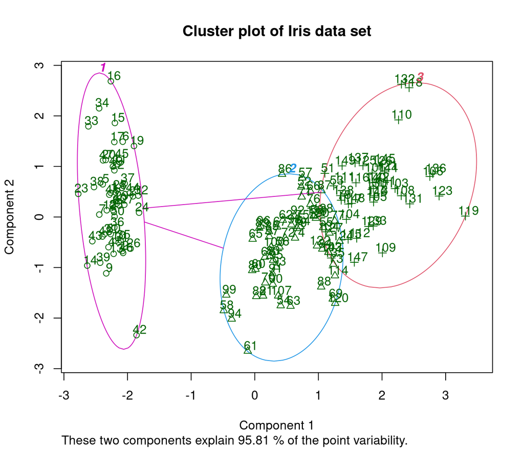

```r
res.upfc3 <- ppclust2(res.upfc, "fanny")

cluster::clusplot(scale(x), res.upfc3$cluster,
  main = "Cluster plot of Iris data set",
  color=TRUE, labels = 2, lines = 2, cex=1)
```

# 4 VALIDATION OF THE CLUSTERING RESULTS

Cluster validation is an evaluation process for the goodness of the clustering result. For this purpose, various validity indexes have been proposed in the related literature. Since clustering is an unsupervised learning analysis which does not use any external information, the internal indexes are used to validate the clustering results. Although there are many internal indexes have originally been proposed for working with hard membership degrees produced by the K-means and its variants, most of these indexes cannot be used for fuzzy clustering results. In R environment, Partition Entropy (PE), Partition Coefficient (PC) and Modified Partition Coefficient (MPC) and Fuzzy Silhouette Index are available in ‘`fclust`’ package (Ferraro & Giordani, 2015), and can be used as follows:

```r
res.upfc4 <- ppclust2(res.upfc, "fclust")
idxsf <- SIL.F(res.upfc4$Xca, res.upfc4$U, alpha=1)
idxpe <- PE(res.upfc4$U)
idxpc <- PC(res.upfc4$U)
idxmpc <- MPC(res.upfc4$U)
```

```r
cat("Partition Entropy: ", idxpe)
```

```
## Partition Entropy:  0.3614377
```

```r
cat("Partition Coefficient: ", idxpc)
```

```
## Partition Coefficient:  0.6169534
```

```r
cat("Modified Partition Coefficient: ", idxmpc)
```

```
## Modified Partition Coefficient:  0.4254301
```

```r
cat("Fuzzy Silhouette Index: ", idxsf)
```

```
## Fuzzy Silhouette Index:  0.8262374
```

# References

Anderson, E. (1935). The irises of the GASPE peninsula, in *Bull. Amer. Iris Soc.*, 59: 2-5.

Ferraro, M.B. & Giordani, P. (2015). A toolbox for fuzzy clustering using the R programming language. *Fuzzy Sets and Systems*, 279, 1-16. http://dx.doi.org/10.1016/j.fss.2015.05.001

Kassambara, A. & Mundt, F. (2017). factoextra: Extract and Visualize the Results of Multivariate Data Analyses. R package version 1.0.5. https://CRAN.R-project.org/package=factoextra

Maechler, M., Rousseeuw, P., Struyf, A., Hubert, M. & Hornik, K.(2017). cluster: Cluster Analysis Basics and Extensions. R package version 2.0.6. https://CRAN.R-project.org/package=cluster

Pal, N. R., Pal, K. & Bezdek, J. C. (2005). A possibilistic fuzzy c-means clustering algorithm. *IEEE Trans. Fuzzy Systems*, 13 (4): 517-530

Yang, M. S. & Wu, K. L. (2006). Unsupervised possibilistic clustering. *Pattern Recognition*, 39(1): 5-21.

Wu, X., Wu, B., Sun, J. & Fu, H. (2010). Unsupervised possibilistic fuzzy clustering. *J. of Information & Computational Sci.*, 7 (5): 1075-1080.